# Data Visualization

Rachel Chang

2019/7/15

#### 動機 : 對網路新聞標題「國家愈有錢，人民愈健康?」產生疑惑，想藉由資料分析進行討論。

## 一、匯入特定資料:

data source1: https://data.worldbank.org/indicator/NY.GDP.MKTP.CD

data source2: https://data.worldbank.org/indicator/SP.DYN.LE00.IN

```r
path = "D:/資料科學程式設計/data_science/week 2_0715/data/GDP2.xlsx"
path2 = "D:/資料科學程式設計/data_science/week 2_0715/data/life2.xlsx"

library(tidyverse)
library(dplyr)
library(readxl)
a = read_excel(path)
b = read_excel(path2)
```

## 二、固定國家

### 分別先觀察低度發展國家(以尼日為例)和高度發展國家(以英國為例)近十年GDP與Life expectancy的關係:

```r
NigerGDP <- select(a,"year","Niger")
NigerLIFE <- select(b,"year","Niger")
data_Niger<-merge(NigerGDP, NigerLIFE, by="year")
colnames(data_Niger)<-c("year" ,"NigerGDP","NigerLIFE")
data_Niger[48:57,]
```

```
##    year   NigerGDP NigerLIFE
## 48 2007 4291363391    54.593
## 49 2008 5379299888    55.350
## 50 2009 5373097441    56.105
## 51 2010 5718664505    56.838
## 52 2011 6409184724    57.528
## 53 2012 6942258305    58.160
## 54 2013 7667952566    58.727
## 55 2014 8229731384    59.228
## 56 2015 7217667781    59.667
## 57 2016 7528285444    60.058
```

### 尼日近十年GDP與Life expectancy的關係

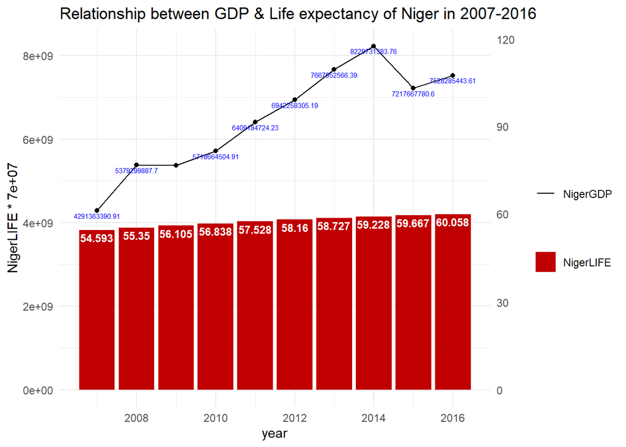

```r
library(ggplot2)
ggplot(data_Niger[48:57,], aes(x = year)) +
  geom_col(aes( y = NigerLIFE*70000000, fill="redfill")) +
  geom_text(aes(y = NigerLIFE*70000000, label = NigerLIFE), fontface = "bold", vjust = 1.4, color = "white", size = 3,check_overlap = TRUE) +
  geom_line(aes(y = NigerGDP , group = 1, color = 'blackline')) +
  geom_text(aes(y = NigerGDP , label = round( NigerGDP, 2)), vjust = 1.4, color = "blue", size = 2,check_overlap = TRUE) +
  geom_point(aes(y = NigerGDP ))+
  scale_y_continuous(sec.axis = sec_axis(trans = ~ . / 70000000)) +
  scale_fill_manual('', labels = 'NigerLIFE', values = "#C00000") +
  scale_color_manual('', labels = 'NigerGDP', values = 'black') +
  ggtitle("Relationship between GDP & Life expectancy of Niger in 2007-2016")+
  theme_minimal()
```

#### 以雙折線圖呈現

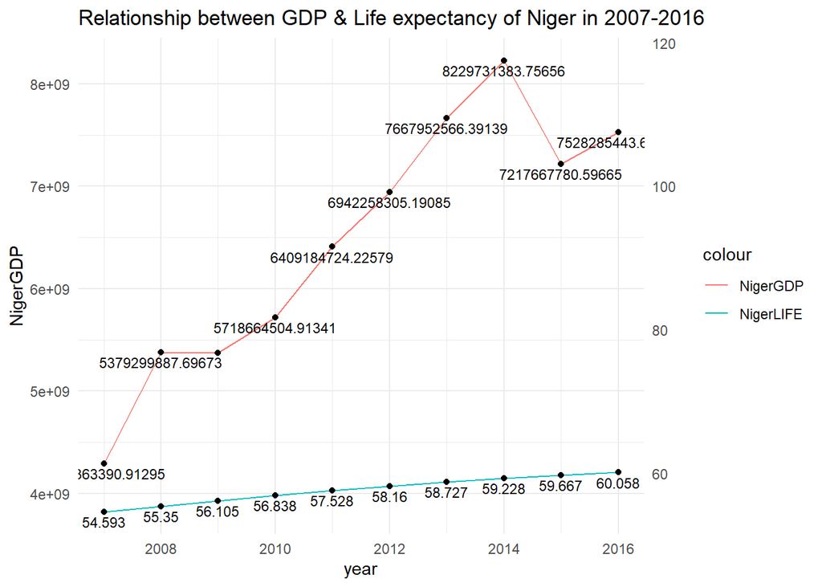

```r
library(ggplot2)
ggplot(data_Niger[48:57,], aes(x = year)) +
  geom_line(aes(y = NigerGDP , group = 1, color = 'NigerGDP'))+
  geom_text(aes(y = NigerGDP, label = NigerGDP), vjust =1.4, color = "black", size = 3,check_overlap = TRUE) +
  geom_point(aes(y = NigerGDP))+
  geom_line(aes(y=NigerLIFE*70000000,  group =1, color = 'NigerLIFE'))+
  geom_text(aes(y = NigerLIFE*70000000, label = NigerLIFE), vjust = 1.4, color = "black", size = 3,check_overlap = TRUE) +
  geom_point(aes(y = NigerLIFE*70000000))+
  scale_y_continuous(sec.axis = sec_axis(trans = ~ . / 70000000)) +
  ggtitle("Relationship between GDP & Life expectancy of Niger in 2007-2016")+
  theme_minimal()
```

```r
UKGDP <- select(a,"year","United Kingdom")
UKLIFE <- select(b,"year","United Kingdom")
data_UK<-merge(UKGDP, UKLIFE, by="year")
colnames(data_UK)<-c("year" ,"UKGDP","UKLIFE")
data_UK[48:57,]
```

```
##    year        UKGDP   UKLIFE
## 48 2007 3.084118e+12 79.44878
## 49 2008 2.904037e+12 79.60000
## 50 2009 2.394786e+12 80.05122
## 51 2010 2.452900e+12 80.40244
## 52 2011 2.634896e+12 80.95122
## 53 2012 2.676605e+12 80.90488
## 54 2013 2.753565e+12 81.00488
## 55 2014 3.034729e+12 81.30488
## 56 2015 2.896421e+12 80.95610
## 57 2016 2.659239e+12 81.15610
```

### 英國近十年GDP與Life expectancy的關係

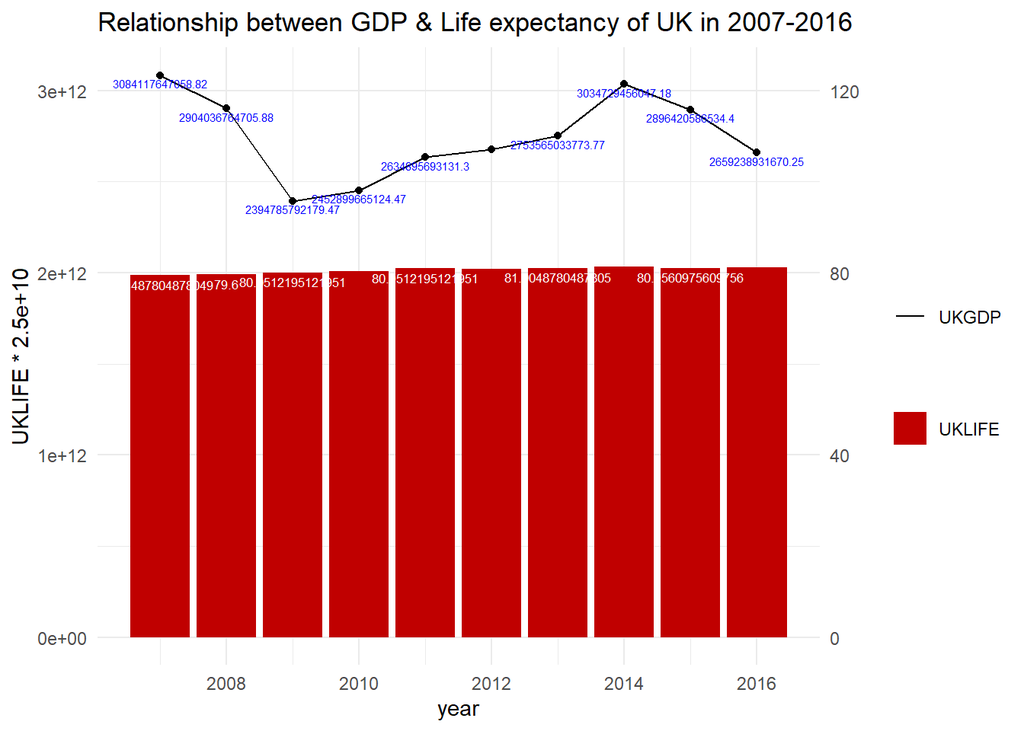

```r
library(ggplot2)
ggplot(data_UK[48:57,], aes(x = year)) +
  geom_col(aes( y = UKLIFE*25000000000, fill="redfill")) +
  geom_text(aes(y = UKLIFE*25000000000, label = UKLIFE) ,vjust = 1.4, color = "white", size =2.2,check_overlap = TRUE) +
  geom_line(aes(y = UKGDP , group = 1, color = 'blackline')) +
  geom_text(aes(y = UKGDP , label = round( UKGDP, 2)), vjust = 1.4, color = "blue", size = 2,check_overlap = TRUE) +
  geom_point(aes(y = UKGDP))+
  scale_y_continuous(sec.axis = sec_axis(trans = ~ . / 25000000000)) +
  scale_fill_manual('', labels = 'UKLIFE', values = "#C00000") +
  scale_color_manual('', labels = 'UKGDP', values = 'black') +
  ggtitle("Relationship between GDP & Life expectancy of UK in 2007-2016")+
  theme_minimal()
```

#### 以雙折線圖呈現

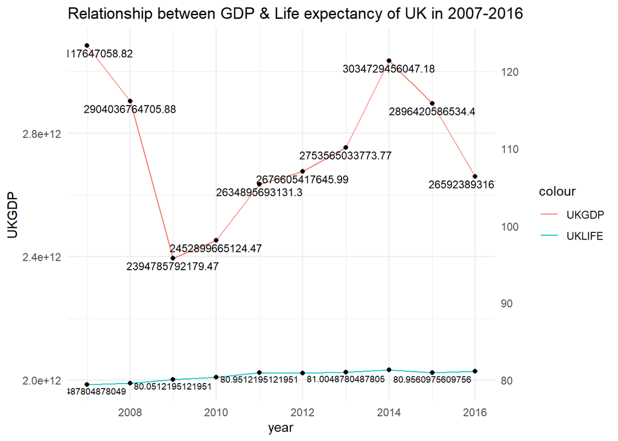

```r
library(ggplot2)
ggplot(data_UK[48:57,], aes(x = year)) +
  geom_line(aes(y = UKGDP , group = 1, color = 'UKGDP'))+
  geom_text(aes(y = UKGDP, label = UKGDP),vjust = 1.4, color = "black", size = 3,check_overlap = TRUE) +
  geom_point(aes(y = UKGDP))+
  geom_line(aes(y= UKLIFE*25000000000,  group =1, color = 'UKLIFE'))+
  geom_text(aes(y = UKLIFE*25000000000, label = UKLIFE), vjust = 1.4, color = "black", size = 2.5,check_overlap = TRUE) +
  geom_point(aes(y= UKLIFE*25000000000))+
  scale_y_continuous(sec.axis = sec_axis(trans = ~ . / 25000000000)) +
  ggtitle("Relationship between GDP & Life expectancy of UK in 2007-2016")+
  theme_minimal()
```

### 由尼日圖表可以觀察到:雖然GDP偶有波動，但和Life expectancy大致呈現正相關；英國圖表卻很難觀察到這種現象，推測可能原因是英國為已開發國家，故關係較不明顯。

## 三、固定年分

### 找出兩者之間的關聯性─鎖定2016年，觀察264個國家之GDP & Life expectancy的關係:

```r
path3 = "D:/資料科學程式設計/data_science/week 2_0715/data/GDP.xlsx"
path4 = "D:/資料科學程式設計/data_science/week 2_0715/data/life.xlsx"

library(dplyr)
library(readxl)
m = read_excel(path3)
n = read_excel(path4)

GDP <- select(m,"Country Name","2016")
LIFE <- select(n,"Country Name","2016")

library(knitr)
GDP_LIFE<-merge(GDP,LIFE, by="Country Name")
colnames(GDP_LIFE)<-c("Country Name" ,"GDP","LIFE")
kable(GDP_LIFE)
```

| Country Name | GDP | LIFE |
| --- | --- | --- |
| Afghanistan | 1.936264e+10 | 63.67300 |
| Albania | 1.186135e+10 | 78.34500 |
| Algeria | 1.601299e+11 | 76.07800 |
| American Samoa | 6.530000e+08 | NA |
| Andorra | 2.877312e+09 | NA |
| Angola | 1.011239e+11 | 61.54700 |
| Antigua and Barbuda | 1.464630e+09 | 76.36400 |
| Arab World | 2.506038e+12 | 71.22691 |
| Argentina | 5.575314e+11 | 76.57700 |
| Armenia | 1.054614e+10 | 74.61800 |
| Aruba | 2.646927e+09 | 75.86700 |
| Australia | 1.210028e+12 | 82.44878 |
| Austria | 3.940528e+11 | 81.64146 |
| Azerbaijan | 3.786752e+10 | 72.02600 |
| Bahamas, The | 1.183880e+10 | 75.67500 |
| Bahrain | 3.225013e+10 | 76.90000 |
| Bangladesh | 2.214152e+11 | 72.48900 |
| Barbados | 4.529050e+09 | 75.90600 |
| Belarus | 4.772266e+10 | 73.82683 |
| Belgium | 4.696772e+11 | 81.43902 |
| Belize | 1.806646e+09 | 70.38400 |
| Benin | 8.573160e+09 | 60.90700 |
| Bermuda | NA | 81.22707 |
| Bhutan | 2.219676e+09 | 70.19700 |
| Bolivia | 3.394113e+10 | 69.12500 |
| Bosnia and Herzegovina | 1.691333e+10 | 76.91100 |
| Botswana | 1.564632e+10 | 66.79700 |
| Brazil | 1.796275e+12 | 75.50900 |
| British Virgin Islands | NA | NA |
| Brunei Darussalam | 1.140065e+10 | 77.20300 |

[output cut: 234 more lines]

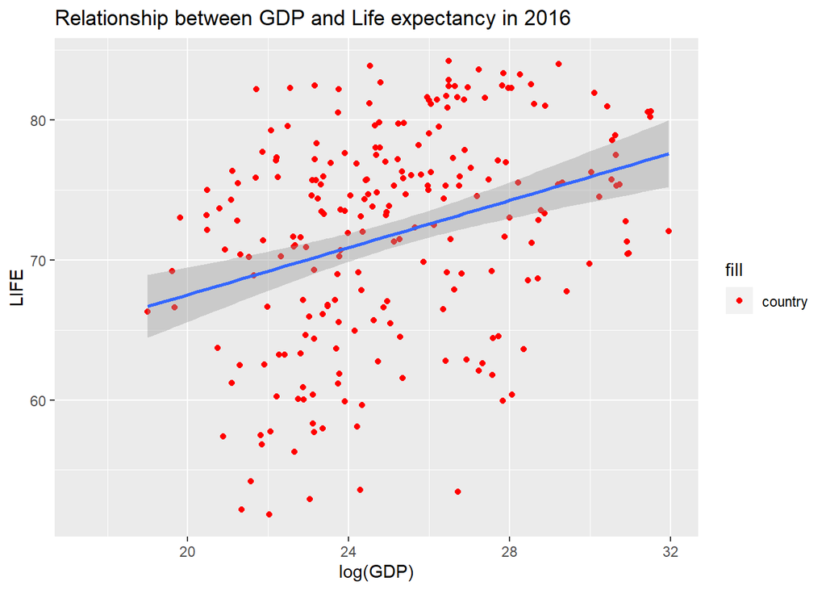

```r
library(ggplot2)
ggplot(GDP_LIFE,aes(x=log(GDP),y=LIFE))+
  geom_point(aes(fill='country'),color="red")+
  geom_smooth(method=lm)+
  ggtitle("Relationship between GDP and Life expectancy in 2016")
```

### 由上圖發現GDP和Life expectancy呈現正相關，但這僅能說明Life expectancy的增加，有部份可能是因為GDP較高。

## 四、進一步討論

data source3: https://www.kaggle.com/sudhirnl7/human-development-index-hdi

```r
path3 = "D:/資料科學程式設計/data_science/week 2_0715/data/GDP.xlsx"
path5 = "D:/資料科學程式設計/data_science/week 2_0715/data/HDI.xlsx"

library(dplyr)
library(readxl)
X = read_excel(path3)
Y = read_excel(path5)

GDP <- select(X,"Country Name","2016")
HDI <- select(Y,"Country Name","2016")

library(knitr)
GDP_HDI<-merge(GDP,HDI, by="Country Name")
colnames(GDP_HDI)<-c("Country Name" ,"GDP","HDI")
kable(GDP_HDI)
```

| Country Name | GDP | HDI |
| --- | --- | --- |
| Afghanistan | 1.936264e+10 | 0.494 |
| Albania | 1.186135e+10 | 0.782 |
| Algeria | 1.601299e+11 | 0.753 |
| Andorra | 2.877312e+09 | 0.856 |
| Angola | 1.011239e+11 | 0.577 |
| Antigua and Barbuda | 1.464630e+09 | 0.778 |
| Argentina | 5.575314e+11 | 0.822 |
| Armenia | 1.054614e+10 | 0.749 |
| Australia | 1.210028e+12 | 0.938 |
| Austria | 3.940528e+11 | 0.906 |
| Azerbaijan | 3.786752e+10 | 0.757 |
| Bahrain | 3.225013e+10 | 0.846 |
| Bangladesh | 2.214152e+11 | 0.597 |
| Barbados | 4.529050e+09 | 0.799 |
| Belarus | 4.772266e+10 | 0.805 |
| Belgium | 4.696772e+11 | 0.915 |
| Belize | 1.806646e+09 | 0.709 |
| Benin | 8.573160e+09 | 0.512 |
| Bhutan | 2.219676e+09 | 0.609 |
| Bosnia and Herzegovina | 1.691333e+10 | 0.766 |
| Botswana | 1.564632e+10 | 0.712 |
| Brazil | 1.796275e+12 | 0.758 |
| Brunei Darussalam | 1.140065e+10 | 0.852 |
| Bulgaria | 5.324095e+10 | 0.810 |
| Burkina Faso | 1.088636e+10 | 0.420 |
| Burundi | 2.959185e+09 | 0.418 |
| Cabo Verde | 1.662999e+09 | 0.652 |
| Cambodia | 2.001675e+10 | 0.576 |
| Cameroon | 3.262154e+10 | 0.553 |
| Canada | 1.526706e+12 | 0.922 |

[output cut: 133 more lines]

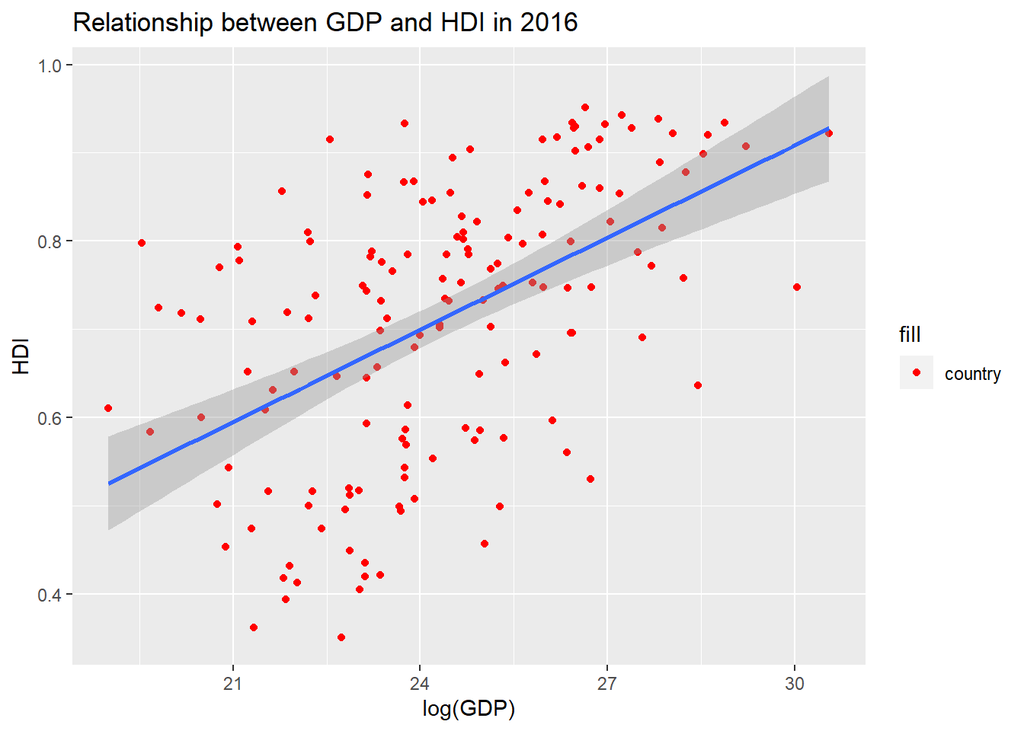

```r
library(ggplot2)
ggplot(GDP_HDI,aes(x=log(GDP), y=HDI)) +
  geom_point(aes(fill='country'),color="red")+
  geom_smooth(method=lm)+
  ggtitle("Relationship between GDP and HDI in 2016")
```

### 結論 : 觀察GDP_LIFE和GDP_HDI兩張散佈圖，兩者均呈現“不完全正相關”。預期人均壽命或教育程度…提升會影響整個國家的生產力，使GDP上升，但逆向論述不一定正確，即GDP的提升(國家經濟發展程度越好)，不完全會使預期人均壽命上升，由GDP的組成也可得到類似的結論。

## 五、綜合作圖:strip chart

### 匯入資料

```r
path6 = "D:/資料科學程式設計/data_science/week 2_0715/data/GDP3.xlsx"
path7 = "D:/資料科學程式設計/data_science/week 2_0715/data/life3.xlsx"

library(dplyr)
library(readxl)
data11 = read_excel(path6)
data12 = read_excel(path7)
```

### 264個國家2012-2016的GDP帶狀圖

```r
gdp_all<- select(data11,"Country Name", "GDP",  "year")
gdp_all
```

```
## # A tibble: 1,320 x 3
##    `Country Name`           GDP  year
##    <chr>                  <dbl> <dbl>
##  1 Aruba                2.53e 9  2012
##  2 Afghanistan          2.00e10  2012
##  3 Angola               1.28e11  2012
##  4 Albania              1.23e10  2012
##  5 Andorra              3.16e 9  2012
##  6 Arab World           2.79e12  2012
##  7 United Arab Emirates 3.75e11  2012
##  8 Argentina            5.46e11  2012
##  9 Armenia              1.06e10  2012
## 10 American Samoa       6.44e 8  2012
## # ... with 1,310 more rows
```

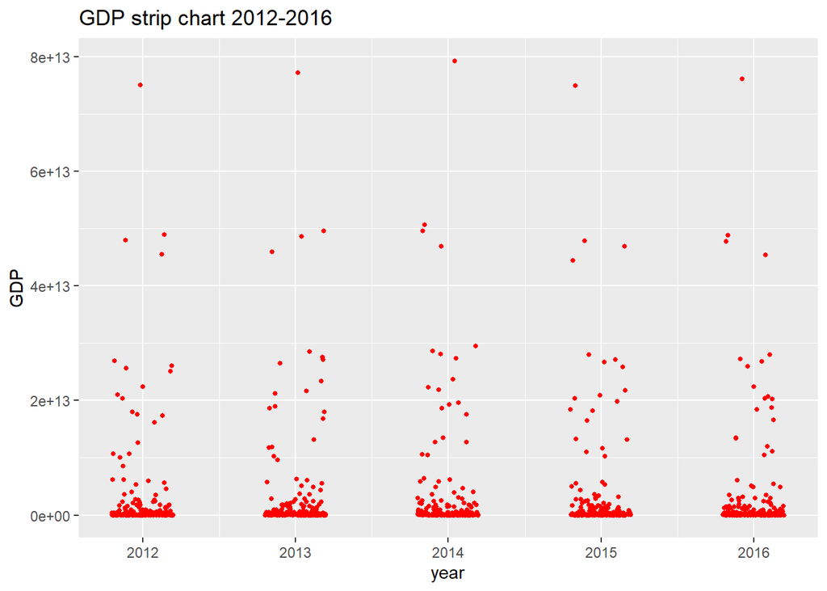

```r
#有遺失值無法繪製箱型圖和計算平均值
library(ggplot2)
ggplot(gdp_all, aes(x=year, y=GDP,group=year)) +
  geom_jitter(position=position_jitter(0.2), cex=1.,color="red")+
  ggtitle("GDP strip chart 2012-2016")
```

### 264個國家2012-2016的life expeatancy帶狀圖

```r
life_all<- select(data12,"Country Name",    "LIFE", "year")
life_all
```

```
## # A tibble: 1,320 x 3
##    `Country Name`        LIFE year
##    <chr>                <dbl> <chr>
##  1 Aruba                 75.3 2012
##  2 Afghanistan           62.1 2012
##  3 Angola                59.8 2012
##  4 Albania               77.4 2012
##  5 Andorra               NA   2012
##  6 Arab World            70.4 2012
##  7 United Arab Emirates  76.6 2012
##  8 Argentina             75.9 2012
##  9 Armenia               73.8 2012
## 10 American Samoa        NA   2012
## # ... with 1,310 more rows
```

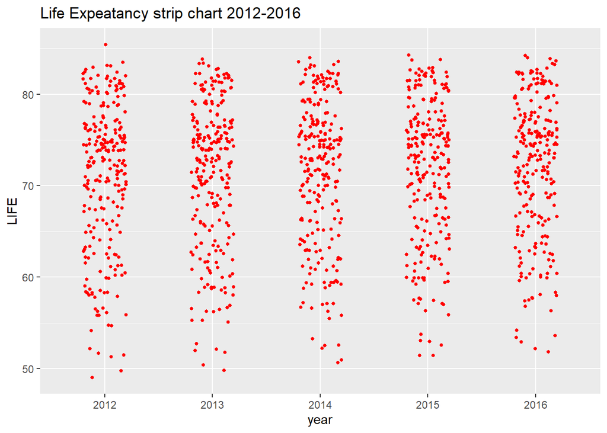

```r
#有遺失值無法繪製箱型圖和計算平均值
library(ggplot2)
ggplot(life_all, aes(x=year, y=LIFE,group=year)) +
  geom_jitter(position=position_jitter(0.2), cex=1.,color="red")+
  ggtitle("Life Expeatancy strip chart 2012-2016")
```